# Appendix D

Process for converting from NZA spreadsheets to *.zoning files

This appendix documents the process by which we created zoning data files according to the Open Zoning Feed Specification (OZFS) format using already-recorded National Zoning Atlas (NZA) data. The main steps are summarized in the sections that follow.

#### Data Preparation

- Gather Needed Data
- Change NZA Column Names
- Clean Up Data
- Add Columns to NZA

#### Run R Script

- Function Descriptions
- Manual Adjustments

## Data Preparation

### Gather Needed Data

The NZA data we had access to contained two files for each city: a tabular file storing the zoning regulations, and a geojson file storing the zoning district geometries. To convert to OZFS, these two files were required for each city. The table below gives more details on the files used in the R script. Because the geometry file stored an abbreviated district name attached to its geometry, we didn’t need to change anything in that file, but there were some changes needed to prepare the tabular data.

| **Data Needed** | **Description** | **Acceptable File Types** |
| --- | --- | --- |
| Tabular Zoning Data | Data stored in NZA-standard tabular format | .csv .xlsx |
| District Geometries | Zoning district geometries with a field for abbreviated district name | .geojson |

### Change NZA Column Names

With the tabular data, we changed the names of each column for easier reading and manipulation in R. As shown in the figure below, the new column name is generally created by the constraint name, as it appears in the OZFS, followed by a representation of the land use.

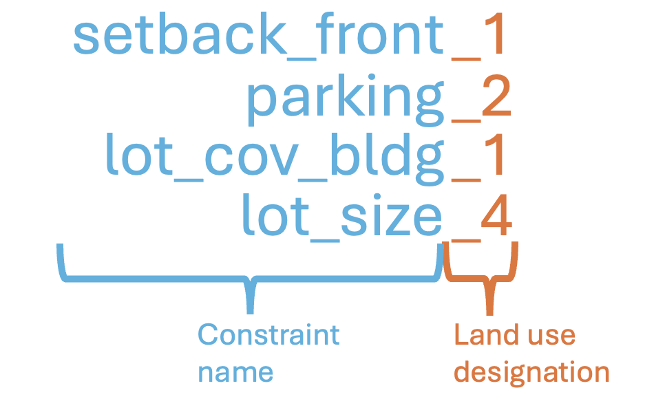

New column naming convention

The land use designations were the string “_1” for 1-family treatments, “_2” for 2-family treatments, “_3”, for 3-family treatments, and “_4” for 4+family treatments. Often townhomes were explained with different requirements, so we also added a “_th” for townhome treatments. A table comparing the NZA column names and the our updated column names is found at the end of this appendix.

### Clean Up Data

Newer versions of the NZA may not have this, but the data we had was often stored inconsistently. For example, some parking requirements would be listed simply as “2” while others would be listed as “2/DU” indicating 2 spaces per dwelling unit. For the code to read the data properly, we needed to go through each cell and make sure it was either a single value or an equation readable by the R code.

An equation was created when the NZA data indicated some dependent value. For example, when the front setback is equal to half of the lot’s width, an equation is needed instead of a single value. Equations were stored as strings. To work with the R script, they could only contain variables acceptable by OZFS, and they needed to follow Python syntax as required by OZFS.

### Add Columns to NZA

#### Columns not recorded in NZA

As part of the data clean-up, there were some columns that needed to be added. A few additions were columns for constraints not recorded in the NZA format but needed for the OZFS format: setback_side_ext, parking_enclosed, parking_uncovered, parking_covered.

While some cities have different setbacks for corner lots with an exterior side and a front side, NZA only has one place to store the side setback value. We used the notes of the excel file to add a value for the exterior side setback.

The parking columns needed to be updated in a similar way. For all but 1-family treatments, the NZA format has two fields for parking requirements: Parking Per Studio/1BR, and Parking Per 2+ BR. To convert to OZFS format, we needed to combine these into one. This was usually assigned to the parking_uncovered column, but parking_covered and parking_enclosed columns could be added if the excel notes specified.

#### Columns to represent conditional constraints

Perhaps the most difficult manual adjustment to the tabular data was adding columns to represent conditional constraints or criteria-based requirements. With these types of constraints, the NZA format often recorded one value and then left a special note about the condition or criteria, but the OZFS has a way to store some of these conditional and criteria-based requirements. The pattern we used for naming these additional columns was based on the OZFS format, which can contain multiple lists of rules describing how a constraint is calculated. The additional fields added to the columns are described as follows.

- **rule:** This was connected to the arrays under the `min_val` or `max_val` fields in OZFS. rule1 denotes the first item in the array of conditions, rule2 denotes the second item in the array of conditions, etc.
- **expression**: This was directly connected to the `expression`, or list of expressions, in the OZFS. Each array will always have at least one expression, so if there were columns added, at least one of them was an expression column. If multiple expressions where present, multiple expression columns were added with a number to distinguish them (`expression1`, `expression2`, etc.).
- **condition**: This was connected to the `condition` field in OZFS which will be present if the constraint value is conditional to another value; like building height, lot width, etc. If it was a regular condition able to be recorded by OZFS standards, the condition was written using Python syntax following OZFS standards. (ex. “height >= 10 and lot_width < 60”). Complex conditions could be written as strings describing the condition. Like the `expression` column, multiple conditions could be stated with multiple columns (`condition1`, `condition2`, etc.).
- **criterion**: This is equivalent to the `min_max` OZFS field which is included when there is a “min” or “max” criterion that determines the constraint value from a list of multiple expressions. It was always followed by multiple `expression` columns.
- **more_restrictive**: This column is not needed with the current version of OZFS but is still part of the R script. The current version of OZFS describes complex conditions using the conditions field, but in some files created before the OZFS was published, “dependent” was added to the `criterion` field and the `more_restrictive` field was used to describe the complex condition. The R script can work with this older method, but it is not recommended for future NZA-OZFS conversions.

When the constraint in the NZA data was recorded as a single value or expression, it was left in the original cell. If there were constraints requiring a conditional rule or a min/max criterion, then new columns were added to the excel file. The names of the new columns followed a specific pattern that stated the rule number and the rule item that was being recorded. This rule number and rule item were placed in between the constraint name and land use designation as shown in the figure below.

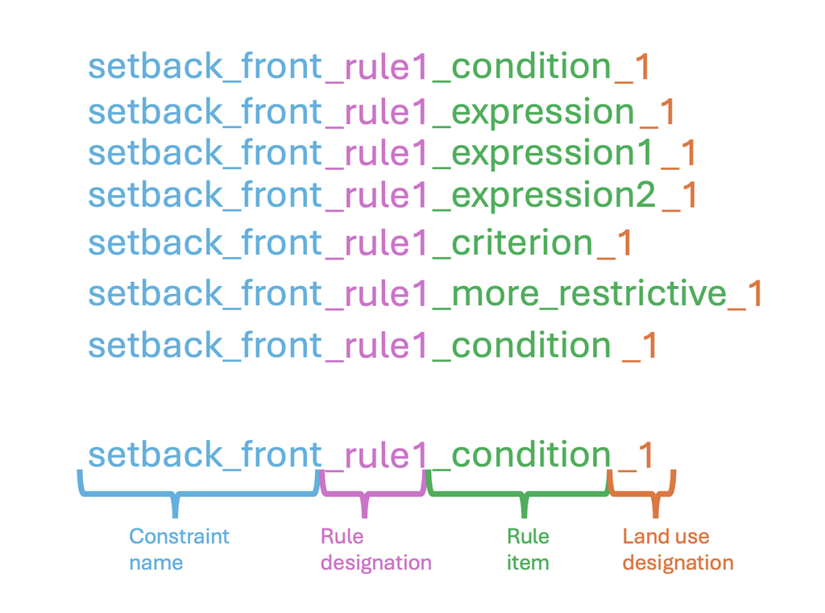

Naming convention for additional columns

To illustrate this, text from an example city’s zoning code is given:

> *For single family homes less than or equal to 36 feet in height, the minimum front setback is equal to the height of the building but need not exceed 30 feet. For single family homes greater than 36 feet in height, the minimum front setback is 40 feet.*

Unlike the NZA, the OZFS standard has a specific way to represent this unique constraint, and the figure below shows how it would be structured. The table shows how this information was added to the NZA excel sheet using the column naming pattern. Note that the original column indicating the name and land use was kept and left blank. This original column left blank was need for the code to work properly.

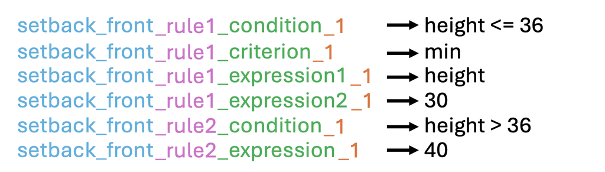

Naming convention example

| **setback_front_1** | **setback_front_rule1_condition_1** | **setback_front_rule1_criterion_1** | **setback_front_rule1_expression1_1** | **setback_front_rule1_expression2_1** | **setback_front_rule2_condition_1** | **setback_front_rule2_expression_1** |
| --- | --- | --- | --- | --- | --- | --- |
|  | height <= 36 | min | height | 30 | height > 36 | 40 |

### Note on tabular data restrictions

Adding extra columns to satisfy conditional requirements sometimes caused problems if there were more than one district with different columns that needed to be added. To make it so the code still read the columns correctly without worrying about NA values, we sometimes added redundant expressions. For example, if District 1 had two conditions that each gave a single constraint value, but District 2 had two conditions that each gave a list of constraint values where the correct value was the max, then District 1 also had to work with extra expression columns even though it wasn’t needed. To avoid empty cells, District 1 would have two expression columns and a criterion column where it would have to choose the maximum value between two of the same values. This technically still follows OZFS format, but it is less efficient.

## Run R Script

After cleaning and preparing the data, we created an R script to convert it to OZFS format. The following sections briefly describe the functions in the script and final adjustments made. The r script is attached at the end of this appendix.

### Function Descriptions

#### make_ozfs()

This is the main function of the R script and has five inputs:

- `nza_files_folder:` The folder containing the NZA tabular data. There was a separate file for each city we were working with.
- `geom_files_folder:` The folder containing the NZA geometry data. It was important to have one file for each individual city in the exact same order as the files for the tabular data.
- `new_folder_to_save_to:` The path to the folder where the *.zoning files would be saved.
- `col_descriptions_path:` The path to an excel sheet we created that listed all the constraint names (in OZFS format) and whether the NZA record the min or max value. See the table below for the contents of the col_descriptions file.
- `extra_overlay_geom_file:` This is an option variable that would take in the file path to a geojson with extra overlay districts that weren’t recorded in the NZA tabular data but were found in geometry files.

col_descriptions file contents

| **col_name** | **min_or_max** |
| --- | --- |
| lot_area | min |
| setback_front | min |
| setback_side_int | min |
| setback_side_ext | min |
| setback_rear | min |
| setback_side_sum | min |
| setback_front_sum | min |
| setback_dist_boundary | min |
| lot_cov_bldg | max |
| parking_enclosed | min |
| parking_covered | min |
| parking_uncovered | min |
| stories | max |
| height | max |
| height_eave | max |
| unit_size | min |
| unit_size_avg | min |
| unit_density | max |
| total_units | max |
| units_0bed | max |
| units_1bed | max |
| units_2bed | max |
| units_3bed | max |
| units_4bed | max |
| unit_pct_0bed | max |
| unit_pct_1bed | max |
| unit_pct_2bed | max |
| unit_pct_3bed | max |
| unit_pct_4bed | max |
| footprint | max |
| fl_area | max |
| fl_area_first | min |
| fl_area_top | min |
| far | max |

The `make_ozfs()` function calls other functions in the script to create a *.zoning file for each city and saves the new files to the specified folder.

#### atlas_to_ozfs()

The `atlas_to_ozfs()` function has the following inputs:

- `nza_file_path:` The path to one NZA file (must be xlsx or csv).
- `col_descriptions:` The col_descriptions data frame created from the col_descriptions file
- `version_date:` The last date that the zoning code was updated.

The function returns a list following OZFS standards that is ready to be transformed into a geojson.

#### organize_feature()

This function is used during the process of creating the OZFS formatted list in the `atlas_to_ozfs()` function. It takes in one row of the zoning atlas data frame (`atlas_row_df`), the `col_descriptions`, and the `use_type_indicators`, and returns a list that mimics what that district’s feature array will be in the OZFS.

#### make_constraints()

As the code loops through each constraint in the `organize_feature()` function, the `make_constraints()` function takes in a data frame of all the constraints (`constraints_df`) and a list that filters the columns of the `atlas_row_df` data for each individual use. It returns a list of the specific constraint section of the OZFS to be added to the feature list being created.

#### organize_rules()

The `make_constraints()` function checks to see if there are columns that indicate conditional rules. If there are, then a filtered data set is created containing only the rules for the specific constraint. Using this `df_with_rules` data frame and the constraint name, the `organize_rules()` function creates a list of all the conditions that would need to be in the OZFS. This is used in the `make_constraints()` function to add to each constraint with conditional requirements.

#### add_geometry_to_ozfs()

Once the above functions are run, the zoning regulations will have been successfully put into list form following the OZFS standards. The `add_geometry_to_ozfs()` function takes the geometry file and matches each district geometry with the correct OZFS feature using the abbreviated district name.

#### add_extra_overlays()

This function is used if there is an `extra_overlay_geom_file` present. It takes the list of NZA-formatted data and adds any other overlays that may not have been part of the original NZA files.

#### write_list_as_json()

This function simply takes the list that was created following OZFS, converts it to geojson format, and writes it as a *.zoning file.

### Manual Adjustments

After running the r script, we made a few manual adjustments to the definitions that appear at the top level of the .zoning file. The R script created generic height and res_type definitions that have common definitions of height and have res_types that match the way NZA represented residential uses. The layout of these generic definitions are shown in the figure below.

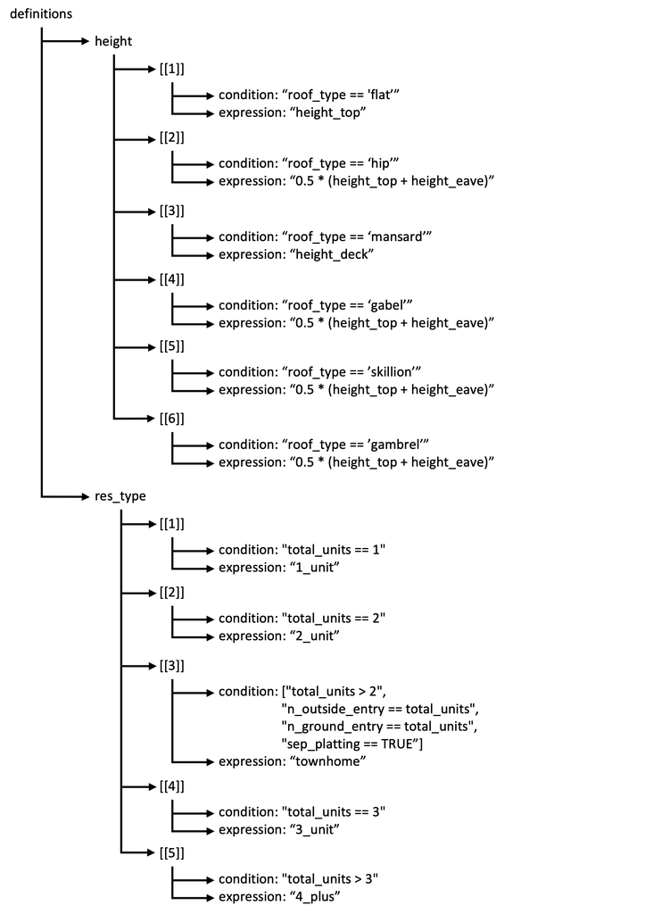

Generic definitions

After updating the generic definitions manually, we created a function called `update_res_types()` that changed any conditions relying on res_type to match the res_type names that were updated manually. To avoid this step in the future, the use_type_indicator values could be stated under the use_type_indicator columns of the tabular data as shown in the example below. The definitions would still need to be manually adjusted.

| use_type_indicator_1 | use_type_indicator_2 | use_type_indicator_3 | use_type_indicator_4 | use_type_indicator_th |
| --- | --- | --- | --- | --- |
| single_family | duplex | triplex | multifamily | townhouse |

## Column Name Comparison

The following table shows the original NZA column names and the updated column names we used for the code to run smoothly.

| **NZA Column Names** | **Updated Column Names** |
| --- | --- |
| Jurisdiction | muni_name |
| County | county |
| Abbreviated District Name | dist_abbr |
| Full District Name | dist_name |
| District Mapped | mapped |
| District Mapped But Extinct | mapped_extinct |
| Overlay | overlay |
| Type of Zoning District | dist_type |
| Affordable Housing District | aff_housing_dist |
| Elderly Housing District | elder_housing_dist |
| NA (optional column we added) | use_type_indicator_1 |
| NA (optional column we added) | use_type_indicator_2 |
| NA (optional column we added) | use_type_indicator_3 |
| NA (optional column we added) | use_type_indicator_4 |
| NA (optional column we added) | use_type_indicator_th |
| 1-Family Treatment | use_permitted_1 |
| 2-Family Treatment | use_permitted_2 |
| 3-Family Treatment | use_permitted_3 |
| 4+-Family Treatment | use_permitted_4 |
| 1-Family Min. Lot (ACRES) | lot_size_1 |
| 1-Family Front Setback (# of feet) | setback_front_1 |
| 1-Family Side Setback (# of feet) | setback_side_int_1 |
| NA (new constraint) | setback_side_ext_1 |
| 1-Family Rear Setback (# of feet) | setback_rear_1 |
| 1-Family Max. Lot Coverage - Buildings (%) | lot_cov_bldg_1 |
| 1-Family Max. Lot Coverage - Buildings & Impervious Surface (%) | lot_cov_imp_1 |
| 1-Family Min. # Parking Spaces | parking_1 |
| 1-Family Max. Height (# of stories) | stories_1 |
| 1-Family Max. Height (# of feet) | height_1 |
| 1-Family Floor to Area Ratio | far_1 |

[output cut: 58 more lines]

## R script

Below is the R script that was used to create the OZFS files from the NZA data.

```r
library(tidyverse)
library(readxl)
library(sf)
library(rjson)

## takes a folder full of nza files and
## a folder full of geometry files that match the nza files in order
## and writes to a new folder all the ozfs .zoning files it created
make_ozfs <- function(nza_files_folder,
                      geom_files_folder,
                      new_folder_to_save_to,
                      col_descriptions_path,
                      extra_overlay_geom_file = NULL){

  nza_files_list <- list.files(nza_files_folder, full.names = TRUE)
  geom_files_list <- list.files(geom_files_folder, full.names = TRUE)

  # import col_descriptions file
  if (file.exists(col_descriptions_path)){
    splt <- strsplit(col_descriptions_path, "[.]")[[1]]
    ext <- splt[[length(splt)]]
    if (ext == "csv"){
      col_descriptions <- read.csv(col_descriptions_path)
    } else if (ext == "xlsx"){
      col_descriptions <- read_excel(col_descriptions_path)
    } else{
      stop("col_descriptions must be .xlsx or .csv")
    }
  } else{
    stop("col_descriptions must be .xlsx or .csv")
  }



  # start empty lists to track errors
  ozfs_errors <- c()
  ozfs_warnings <- c()
  geom_errors <- c()
  geom_warnings <- c()
  overlay_errors <- c()
  overlay_warnings <- c()

  # loop through each NZA file
  for (i in 1:length(nza_files_list)){
    nza_file_path <- nza_files_list[[i]]

    file_name <- basename(nza_files_list[[i]])
    file_name_no_ext <- sub(".xlsx","",file_name)




    ozfs_list_format <- tryCatch(
      {
        # Code that might throw an error
        atlas_to_ozfs(nza_file_path,
                      col_descriptions,
                      version_date = "2024-08-14")
      }, warning = function(w) {
        return(c("warning",paste(w$message,nza_file_path)))
      }, error = function(e) {
        # Code to run if an error occurs
        return(c("error",paste(e$message,nza_file_path)))

      }
    )

    if (ozfs_list_format[[1]] == "warning"){
      ozfs_warnings <- c(ozfs_warnings, ozfs_list_format[[2]])
    }
    if (ozfs_list_format[[1]] == "error"){
      ozfs_errors <- c(ozfs_errors, ozfs_list_format[[2]])
    }

    ozfs_list_with_geom <- tryCatch(
      {
        # Code that might throw an error
        add_geometry_to_ozfs(geom_files_list[[i]], ozfs_list_format)
      }, warning = function(w) {
        return(c("warning",paste(w$message,nza_file_path)))
      },
      error = function(e) {
        # Code to run if an error occurs
        return(c("error",paste(e$message,nza_file_path)))

      }
    )

    if (ozfs_list_with_geom[[1]] == "warning"){
      geom_warnings <- c(geom_warnings, ozfs_list_with_geom[[2]])
    }
    if (ozfs_list_with_geom[[1]] == "error"){
      geom_errors <- c(geom_errors, ozfs_list_with_geom[[2]])
    }


    if (!is.null(extra_overlay_geom_file)){
      ozfs_list_with_geom <- tryCatch(
        {
          # Code that might throw an error
          add_extra_overlays(extra_overlay_geom_file, ozfs_list_with_geom)
        }, warning = function(w) {
          return(c("warning",paste(w$message,nza_file_path)))
        },
        error = function(e) {
          # Code to run if an error occurs
          return(c("error",paste(e$message,nza_file_path)))

        }
      )

      if (ozfs_list_with_geom[[1]] == "warning"){
        overlay_warnings <- c(ozfs_warnings, ozfs_list_format[[2]])
      }
      if (ozfs_list_with_geom[[1]] == "error"){
        overlay_errors <- c(ozfs_errors, ozfs_list_format[[2]])
      }
    }

    new_file_directory <- paste0(new_folder_to_save_to, file_name_no_ext, ".zoning")
    write_list_as_json(ozfs_list_with_geom, new_file_directory)
  }

  if (!is.null(extra_overlay_geom_file)){
    list(ozfs_errors = ozfs_errors,
         ozfs_warnings = ozfs_warnings,
         geom_errors = geom_errors,
         geom_warnings = geom_warnings,
         overlay_errors = geom_errors,
         overlay_warnings = geom_warnings)
  } else{
    list(ozfs_errors = ozfs_errors,
         ozfs_warnings = ozfs_warnings,
         geom_errors = geom_errors,
         geom_warnings = geom_warnings)
  }

}

## Returns a list following OZFS standards
## that is ready to be switched to a geojosn
atlas_to_ozfs <- function(nza_file_path, #Path to one NZA file (must be xlsx or csv)
                          col_descriptions, #col_descriptions data frame
                          version_date = "2024-08-14"){ #the date the zoning ordinance was updated

  if (file.exists(nza_file_path)){
    splt <- strsplit(nza_file_path, "[.]")[[1]]
    ext <- splt[[length(splt)]]
    if (ext == "csv"){
      atlas_df <- read_csv(nza_file_path, col_types = cols(.default = "c"))
    } else if (ext == "xlsx"){
      atlas_df <- read_excel(nza_file_path, col_types = "text")
    } else{
      stop("nza_file_path must be .xlsx or .csv")
    }
  } else{
    stop("nza_file_path must be .xlsx or .csv")
  }

  if (TRUE %in% grepl("use_type_indicator",names(atlas_df))){
    use_type_df <- atlas_df[1,grep("use_type_indicator", names(atlas_df))]
    use_type_indicators <- lapply(names(use_type_df), function(x){
      split_vec <- strsplit(x,"_")[[1]]
      last_item <- split_vec[length(split_vec)]
      return(paste0("_",last_item))
    })
    names(use_type_indicators) <- unlist(as.list(use_type_df))
  } else{
    # establish use_type_indicators
    use_type_indicators <- list(`1_unit` = "_1",
                                `2_unit` = "_2",
                                `3_unit` = "_3",
                                `4_plus` = "_4",
                                `townhome` = "_th")
  }


  # start the geojson list with an empty features list
  ozfs_format <- list(type = "FeatureCollection",
                      version = "0.5.0",
                      muni_name = atlas_df[[1,"muni_name"]],
                      date = version_date,
                      definitions = list(height = list(list(condition = "roof_type == 'flat'",
                                                            expression = "height_top"),
                                                       list(condition = "roof_type == 'hip'",
                                                            expression = "0.5 * (height_top + height_eave)"),
                                                       list(condition = "roof_type == 'mansard'",
                                                            expression = "height_deck"),
                                                       list(condition = "roof_type == 'gable'",
                                                            expression = "0.5 * (height_top + height_eave)"),
                                                       list(condition = "roof_type == 'skillion'",
                                                            expression = "0.5 * (height_top + height_eave)"),
                                                       list(condition = "roof_type == 'gambrel'",
                                                            expression = "0.5 * (height_top + height_eave)")),
                                         res_type = list(list(condition = "total_units == 1",
                                                               expression = "'1_unit'"),
                                                          list(condition = "total_units == 2",
                                                               expression = "'2_unit'"),
                                                         list(condition = list("total_units > 2",
                                                                               "n_outside_entry == total_units",
                                                                               "n_ground_entry == total_units",
                                                                               "sep_platting == TRUE"),
                                                              expression = "'townhome'"),
                                                          list(condition = "total_units == 3",
                                                               expression = "'3_unit'"),
                                                          list(condition = "total_units > 3",
                                                               expression = "'4_plus'"))),
                      features = list())
```

```r
  # loop through each row of atlas_df
  for (i in 1:nrow(atlas_df)){
    atlas_row_df <- atlas_df[i,]
    ozfs_format$features[[i]] <- organize_feature(atlas_row_df,
                                                   col_descriptions,
                                                   use_type_indicators)

  }

  ozfs_format
}

## Returns a list representing one feature of the geojson
## (one feature is one zoning district)
organize_feature <- function(atlas_row_df,
                             col_descriptions,
                             use_type_indicators){

  # create a list with a column for
  separated_uses <- use_type_indicators
  uses_permitted <- c()
  for (i in 1:length(use_type_indicators)){
    use_name <- names(use_type_indicators)[[i]]
    indicator <- use_type_indicators[[i]]

    filtered_columns <- atlas_row_df[,grep(indicator, names(atlas_row_df))]

    if (ncol(filtered_columns) == 0){
      separated_uses[[i]] <- NULL
      next
    }

    names(filtered_columns) <- gsub(indicator,"",names(filtered_columns))

    if (!is.na(filtered_columns$use_permitted) & filtered_columns$use_permitted == "Allowed/Conditional"){
      uses_permitted <- c(uses_permitted, use_name)
    }

    separated_uses[[i]] <- filtered_columns
  }


  # start with a bare list for the features data to fill
  features_list <- list(type = "Feature",
                        properties = list(),
                        geometry = list())

  # add the properties

  # dist_name
  if (!is.na(atlas_row_df[[1,"dist_name"]])){
    features_list$properties[["dist_name"]] <- atlas_row_df[[1,"dist_name"]]
  }

  # dist_abbr
  if (!is.na(atlas_row_df[[1,"dist_abbr"]])){
    features_list$properties[["dist_abbr"]] <- atlas_row_df[[1,"dist_abbr"]]
  }

  # planned_dev
  if (is.na(atlas_row_df[[1,"dist_abbr"]])){
    features_list$properties$planned_dev <- FALSE
  } else if (atlas_row_df[[1,"dist_abbr"]] == "PD" | atlas_row_df[[1,"dist_abbr"]] == "PRD"){
    features_list$properties$planned_dev <- TRUE
  } else{
    features_list$properties$planned_dev <- FALSE
  }

  # overlay
  if (is.na(atlas_row_df[[1,"overlay"]])){
    features_list$properties$overlay <- FALSE
  } else if (atlas_row_df[[1,"overlay"]] == "No"){
    features_list$properties$overlay <- FALSE
  } else{
    features_list$properties$overlay <- TRUE
    return(features_list)
  }

  # res_types_allowed
  if (length(uses_permitted) > 0){
    features_list$properties$res_types_allowed <- uses_permitted
  }

  # constraints

  # filter col_descriptions to just the constraint columns this district has
  constraints_df <- col_descriptions |>
    filter(col_name %in% gsub("_[^_]+$","",names(atlas_row_df)))

  if (nrow(constraints_df) > 0){
    features_list$properties$constraints <- make_constraints(constraints_df, separated_uses)
  }

  if (length(features_list$properties$constraints) == 0){
    features_list$properties$constraints <- NULL
  }

  return(features_list)
}

# prepares the constraints section
make_constraints <- function(constraints_df, separated_uses){

  constraints_list <- list()
  for (i in 1:nrow(constraints_df)){
    constraint_name <- constraints_df$col_name[[i]]
    min_or_max <- constraints_df$min_or_max[[i]]

    if (min_or_max == "min"){
      minmax_vals <- c("min_val","max_val")
    } else{
      minmax_vals <- c("max_val","min_val")
    }

    for (minmax_loop in 1:2){

      if (minmax_loop == 2){
        new_constraint_name <- paste0(constraint_name, "_minmax")
      } else{
        new_constraint_name <- constraint_name
      }

      filtered_separated_uses <- separated_uses
      for (j in 1:length(separated_uses)){
        constraint_data <- separated_uses[[j]]
        filtered_data <- constraint_data |>
          select(grep(constraint_name,names(constraint_data), value = TRUE))

        if (minmax_loop == 1){
          filtered_data <- filtered_data |>
            select(!grep("minmax",names(filtered_data), value = TRUE))
        } else {
          filtered_data <- filtered_data |>
            select(grep("minmax",names(filtered_data), value = TRUE))
        }

        # if filtered_data is blank or NA,
        # it means there is no value for that constraint
        # we make either of those scenarios NULL so that it gets the proper use groupings
        if (ncol(filtered_data) == 0){
          filtered_data <- NA
        } else if (rowSums(is.na(filtered_data)) == ncol(filtered_data)){
          filtered_data <- NA
        } else if (rowSums(is.na(filtered_data)) + 1 == ncol(filtered_data) &
                   !is.na(filtered_data[[new_constraint_name]])){
          filtered_data <- filtered_data[,new_constraint_name]
        }



        filtered_separated_uses[[j]] <- filtered_data
      }

      # Create a unique key for each data frame by serializing to a character string
      key_vec <- sapply(filtered_separated_uses, function(x) paste(serialize(x, NULL), collapse = "-"))

      # Group the list element names by the serialization key
      grouped_uses <- split(names(filtered_separated_uses), key_vec)

      rule_list <- list()
      grouped_uses_count <- length(grouped_uses)
      for (use_group in grouped_uses){

        conditions_string <- paste0("res_type == '", use_group,"'")
        use_condition <- paste(conditions_string, collapse = " or ")

        one_use <- use_group[[1]]
        use_df <- filtered_separated_uses[[one_use]]

        if (class(use_df)[[1]] == "logical"){
          grouped_uses_count <- grouped_uses_count - 1
          next
        }

        organized_rules <- organize_rules(use_df, new_constraint_name)

        if (grouped_uses_count > 1 & !is.null(organized_rules)){

          for (rule_num in 1:length(organized_rules)){
            organized_rules[[rule_num]][["condition"]] <- append(organized_rules[[rule_num]][["condition"]], use_condition)
          }
        }

        rule_list <- append(rule_list, organized_rules)
      }

      # only add the organized rule list to the constraints list if it has values
      if (length(rule_list) > 0){
        constraints_list[[constraint_name]][[minmax_vals[[minmax_loop]]]] <- rule_list
      }
    }
```

```r
  }

  return(constraints_list)

}

# prepares the itmes under min_val or max_val
organize_rules <- function(df_with_rules, constraint_name){

  # this is to check if the df_with_rules is NA
  # which means there was no value recorded
  if (class(df_with_rules)[[1]] == "logical"){
    return(NULL)
  }

  # find out how many rules there are
  counter <- 1
  df <- df_with_rules[1,grep(paste0("rule", counter), names(df_with_rules))]


  while (ncol(df) > 0){
    counter <- counter + 1
    df <- df_with_rules[1 ,grep(paste0("rule", counter), names(df_with_rules))]
  }

  rules_count <- counter - 1

  df_just_rules <- df_with_rules[1 ,grep(paste0(constraint_name, "_rule"), names(df_with_rules))]
  if (is.null(df_with_rules[[constraint_name]])){
    df_no_rules <- data.frame(constraint = NA)
  } else{
    df_no_rules <- df_with_rules[1 ,constraint_name]
  }

  if (!is.na(df_no_rules[[1,1]])){
    rule_list <- list(list(expression = df_with_rules[1,1][[1]]))
    return(rule_list)
  } else if (rowSums(is.na(df_just_rules)) == ncol(df_just_rules)){
    return(NULL)
  }

  # loop through each rule and make it a list
  all_rule_list <- list()
  for (i in 1:rules_count){
    # create a list that we will keep adding to
    rule_list <- list()

    # New df with an isolated rule
    rule_df <- df_with_rules[ ,grep(paste0(constraint_name,"_rule", i), names(df_with_rules))]

    # if it has one of the fields, we will add it to rule_list

    logical_operator <- NULL
    # logical_operator
    if (sum(grep("logical_operator", names(rule_df))) > 0 ){
      # assign value to logical_operator
      logical_operator <- rule_df[[1, grep("logical_operator",names(rule_df))]]
    }

    # conditions
    if (sum(grep("condition", names(rule_df))) > 0 ){
      # make a df to assign multiple values to the array of conditions
      condition_df <- rule_df[ , grep("condition",names(rule_df))]

      if (is.null(logical_operator)){
        condition_value <- condition_df[[1,1]]
      } else{
        condition_list <- c()
        for (j in 1:ncol(condition_df)){
          condition_list <- c(condition_list,condition_df[[1,j]])
        }
        condition_value <- paste(condition_list, collapse = paste0(" ", tolower(logical_operator), " "))
      }
      rule_list$condition <- append(rule_list$condition,condition_value)

    }

    # criterion (was changed to min_max)
    if (sum(grep("criterion", names(rule_df))) > 0 ){

      criterion <- rule_df[[1, grep("criterion",names(rule_df))[1]]]

      if (criterion == "dependent"){
        if (sum(grep("more_restrictive", names(rule_df))) > 0){
          if (!is.na(rule_df[[1, grep("more_restrictive",names(rule_df))[1]]])){
            rule_list$condition <- append(rule_list$condition, rule_df[[1, grep("more_restrictive",names(rule_df))[1]]])
          } else{
            rule_list$condition <- append(rule_list$condition, "Special condition that wasn't stated")
          }
        } else{ # there is no explanation for some reason
          rule_list$condition <- append(rule_list$condition, "Special condition that wasn't stated")
        }
      } else{
        rule_list$min_max <- rule_df[[1, grep("criterion",names(rule_df))[1]]]
      }
    }

    # expression(s)
    if (sum(grep("expression", names(rule_df))) > 0 ){
      # make a df to see if it is more than one expression and to extract data
      df_expression <- rule_df[ , grep(paste0("expression"), names(rule_df))]

      for (j in 1:ncol(df_expression)){
        rule_list$expression[[j]] <- as.character(df_expression[[1,j]])
      }

    }
    # add each rule list to the total rules list
    all_rule_list[[i]] <- rule_list
  }

  return(all_rule_list)
}

# Matches the the districts of the zoning info to
# the districts in the geometry file
add_geometry_to_ozfs <- function(boundary_file_path, ozfs_list){

  boundaries <- rjson::fromJSON(file = boundary_file_path)
  for (i in 1:length(ozfs_list$features)){
    zoning_dist_abbr <- ozfs_list$features[[i]]$properties$dist_abbr
    city <- ozfs_list$features[[i]]$properties$muni_name
    for (j in 1:length(boundaries$features)){
      boundary_dist_name <- boundaries$features[[j]]$properties$`Abbreviated District Name`
      if (zoning_dist_abbr == boundary_dist_name){
        ozfs_list$features[[i]]$geometry <- boundaries$features[[j]]$geometry
      }
    }
  }
  ozfs_list
}

# Takes the output of the add_geometry_to_ozfs() function searches through
# an sf object with extra overlays to add any features to the ozfs format.
# The sf object must have dist_name, dist_abbr, muni_name, and geometry
add_extra_overlays <- function(extra_overlay_geom_file, ozfs_list){
  extra_overlays <- fromJSON(file = extra_overlay_geom_file)

  city_idx <- c()
  for (k in 1:length(extra_overlays$features)){
    if (extra_overlays$features[[k]]$properties$muni_name == ozfs_list$muni_name){
      city_idx <- c(city_idx, k)
    }
  }

  for (i in city_idx){
    overlay_feature_i <- extra_overlays$features[[i]]
    abbr <- overlay_feature_i$properties$dist_abbr

    # find the feature in ozfs_list
    feature <- 0
    for (j in 1:length(ozfs_list$features)){
      if (ozfs_list$features[[j]]$properties$dist_abbr == abbr){
        feature <- ozfs_list$features[[j]]
        break
      }
    }

    if (class(feature) == "list"){ # if the feature exists, we add geometry
      ozfs_list$features[[j]]$geometry <- overlay_feature_i$geometry
    } else{ # if the feature doesn't exist, we create a new feature and add it
      # add a new feature
      overlay_feature_i$properties$muni_name <- NULL
      overlay_feature_i$properties$planned_dev <- ifelse(abbr %in% c("PD","PRD"),TRUE,FALSE)
      overlay_feature_i$properties$overlay <- TRUE

      # add a the overlay feature to the end of the features
      ozfs_list$features[[length(ozfs_list$features) + 1]] <- overlay_feature_i
    }


  }

  return(ozfs_list)
}

# writes a list as a json and
# stores it in specified file
write_list_as_json <- function(list, file_directory){
  json <- toJSON(list)
  write(json, file_directory)
}
```

```r
## Here is an example of what the code looks like
# make_ozfs(nza_files_folder = "file_path_to_nza_excel_files",
#           geom_files_folder = "file_path_to_nza_geom_files",
#           new_folder_to_save_to = "file_path_to_nza_ozfs_files",
#           col_descriptions_path = "file_path_to_col_descriptions_sheet",
#           extra_overlay_geom_file = "file_path_to_the_extra_overlays_data")



###########################
###########################
# The following functions are not needed, but helped us
# make sure the ozfs files were transfered correctly
###########################
###########################

# this function helps see if there were errors in the ozfs files
ozfs_validate <- function(list_of_files){

  # start the empty list where we will store errors
  error_list <- list()

  # loop through each file
  for (file in list_of_files){
    list_of_errors <- c() # can have multiple per file. will combine at the end
    list_of_warnings <- c()

    file_name <- basename(file)

    # CHECK GEOJSON COMPATIBILITY #
    ozfs_listed <- tryCatch(
      {
        fromJSON(file = file)
      }, error = function(e) {
        # Code to run if an error occurs
        return("error")
      }
    )

    if (class(ozfs_listed) == "character"){
      error_list[[file_name]]$errors <- "not geojson format"
      next
    }

    # CHECK CITY_NAME, VERSION, AND DATE #
    if (is.null(ozfs_listed$muni_name)){
      list_of_errors <- c(list_of_errors, "no muni_name field")
    }

    if (is.null(ozfs_listed$version)){
      list_of_errors <- c(list_of_errors, "no version field")
    }

    if (is.null(ozfs_listed$date)){
      list_of_errors <- c(list_of_errors, "no date field")
    }

    # CHECK DEFINITIONS #

    if (!"height" %in% names(ozfs_listed$definitions)){
      list_of_errors <- c(list_of_errors, "no height def.")
    }

    if (!"res_type" %in% names(ozfs_listed$definitions)){
      list_of_errors <- c(list_of_errors, "no res_type def.")
    }

    # CHECK FEATURES #
    # loop through each feature
    for (feature_idx in 1:length(ozfs_listed$features)){

      properties <- ozfs_listed$features[[feature_idx]]$properties

      if (is.null(properties$dist_abbr)){ # check for dist_abbr
        dist_abbr <- feature_idx # variable to use in the warnings
        list_of_warnings <- c(list_of_warnings, paste(dist_abbr,": no dist_abbr field"))
      } else{
        dist_abbr <- properties$dist_abbr # variable to use in warnings
      }

      # if there are constraints, then it will
      # save them as a variable to loop through later
      if (!is.null(properties$constraints)){
        constraints <- properties$constraints
      } else{
        break
      }

      # possible constraint names that could be listed
      possible_constraint_names <- c("lot_area",
                                     "setback_front",
                                     "setback_side_int",
                                     "setback_side_ext",
                                     "setback_rear",
                                     "setback_side_sum",
                                     "setback_front_sum",
                                     "setback_dist_boundary",
                                     "lot_cov_bldg",
                                     "parking_enclosed",
                                     "parking_covered",
                                     "parking_uncovered",
                                     "stories",
                                     "height",
                                     "height_eave",
                                     "unit_size",
                                     "unit_size_avg",
                                     "unit_density",
                                     "total_units",
                                     "units_0bed",
                                     "units_1bed",
                                     "units_2bed",
                                     "units_3bed",
                                     "units_4bed",
                                     "unit_pct_0bed",
                                     "unit_pct_1bed",
                                     "unit_pct_2bed",
                                     "unit_pct_3bed",
                                     "unit_pct_4bed",
                                     "footprint",
                                     "fl_area",
                                     "fl_area_first",
                                     "fl_area_top",
                                     "far")

      # possible variables that could be used in expressions
      # given a random value just so they will be evaluated correctly
      lot_width <- 1
      lot_depth <- 1
      lot_area <- 1
      lot_type <- "corner"
      bedrooms <- 1
      total_bedrooms <- 1
      units_0bed <- 1
      units_1bed <- 1
      units_2bed <- 1
      units_3bed <- 1
      units_4bed <- 1
      total_units <- 1
      fl_area <- 1
      fl_area_bottom <- 1
      parking_covered <- 1
      parking_uncovered <- 1
      parking_enclosed <- 1
      parking_floors <- 1
      parking_bel_grade <- "yes"
      garage_entry <- "front"
      height <- 1
      height_eave <- 1
      floors <- 1
      min_unit_size <- 1
      max_unit_size <- 1
      far <- 1
      bldg_width <- 1
      bldg_dpth <- 1
      level_units_table <- 1
      units_floor1 <- 1
      units_floor2 <- 1
      units_floor3 <- 1
      res_type <- "1_unit"


      # stating which constraints are written properly
      proper_constraint_names <- names(constraints) %in% possible_constraint_names

      # if there are any constraints not written correctly,
      # a warning note is given
      if (FALSE %in% proper_constraint_names){
        incorrect_constraint_names <- names(constraints)[proper_constraint_names == FALSE]
        list_of_warnings <- c(list_of_warnings, paste("bad constraint names:",paste(incorrect_constraint_names, collapse = ", ")))
      }

      # CHECK INDIVIDUAL CONSTRAINTS #
      # loop through each constraint
      for (constraint_idx in 1:length(constraints)){
        constraint_name <- names(constraints)[[constraint_idx]]
        constraint_list <- constraints[[constraint_idx]]
```

```r
        if (!is.null(constraint_list$min_val) & !is.null(constraint_list$max_val)){
          minmax_vals <- c("min_val","max_val")
        } else if (!is.null(constraint_list$min_val)){
          minmax_vals <- "min_val"
        } else if (!is.null(constraint_list$max_val)){
          minmax_vals <- "max_val"
        } else{
          list_of_errors <- c(list_of_errors, paste(dist_abbr,": no min or max vals for",constraint_name))
        }

        # Loop through the value lists
        for (minmax_idx in 1:length(minmax_vals)){
          minmax_name <- minmax_vals[[minmax_idx]]
          minmax <- constraint_list[[minmax_name]]


          # Loop through each item in the value list
          for (condition_num in 1:length(minmax)){
            val_list <- minmax[[condition_num]]

            if (is.null(val_list$expression)){ # expression field is required
              list_of_errors <- c(list_of_errors, paste(dist_abbr,": no expression for",minmax_name, "of",constraint_name))
            } else{
              parsed_expression <- tryCatch(
                {
                  parse(text = val_list$expression)
                }, error = function(e) {
                  # Code to run if an error occurs
                  return("error")
                }
              )

              if (class(parsed_expression) == "character"){ # # expressions must parse properly
                list_of_errors <- c(list_of_errors, paste(dist_abbr,": expression parse error for",minmax_name, "of",constraint_name))
              } else{
                eval_expression <- tryCatch(
                  {
                    eval(parsed_expression)
                  }, error = function(e) {
                    # Code to run if an error occurs
                    return("error")
                  }
                )
                if (class(eval_expression) == "character"){ # expressions must evaluate properly
                  list_of_errors <- c(list_of_errors, paste(dist_abbr,": expression eval error for",minmax_name, "of",constraint_name))
                }
                if (is.na(eval_expression)){ # NAs shouldn't exist
                  list_of_warnings <- c(list_of_warnings, paste(dist_abbr,": NA expression encountered for",minmax_name, "of",constraint_name))
                }
              }
            }

            if (!is.null(val_list$min_max)){
              if (!val_list$min_max %in% c("min","max")){
                # if min_max is something besides "min" or "max" it will cause en error
                list_of_errors <- c(list_of_errors, paste(dist_abbr,": improper min_max for",minmax_name, "of",constraint_name))
              }
              if (length(val_list$expression) == 1){
                # if there is a min_max, there should be multiple values in expression
                list_of_warnings <- c(list_of_warnings, paste(dist_abbr,": min_max not needed",minmax_name, "of",constraint_name))
              }
            }


          } # end loop through each item in the value list

        } # end loop through the value lists

      } # end loop through each constraint

    } # end loop through each feature



    if (length(list_of_warnings) > 0){
      error_list[[file_name]]$warnings <- list_of_warnings
    }
    if (length(list_of_errors) > 0){
      error_list[[file_name]]$errors <- list_of_errors
    }

  } # end loop through each file


  if (length(error_list) == 0){
    return(cat("Files appear to follow proper OZFS standards \n"))
  } else if (length(error_list) == 1){
    cat("There was",paste(length(error_list), "file with errors or warnings \n\n"))
  } else{
    cat("There were",paste(length(error_list), "files with errors or warnings \n\n"))
  }

  return(error_list)
}

# this function is only needed if there are different res_types than the default and they werent added to the tabular data.
update_res_types <- function(res_types_file_path, ozfs_folder_path, path_to_save_files){
  if (!dir.exists(path_to_save_files)){
    dir.create(path_to_save_files)
  }

  res_types_df <- read.csv(res_types_file_path)
  list_of_files <- list.files(ozfs_folder_path, full.names = TRUE)

  # keep track of unchanged files
  unchanged_files <- c()

  # loop through each file
  for (file_idx in 1:length(list_of_files)){
    file <- list_of_files[[file_idx]]
    file_name <- basename(file)
    # Read lines from file
    text <- readLines(file)

    if (!file_name %in% res_types_df$city_file_name){
      unchanged_files <- c(unchanged_files, file_name)
      next
    }

    res_types_list <- c(`1_unit` = res_types_df[res_types_df$city_file_name == file_name,"X1_unit"],
                        `2_unit` = res_types_df[res_types_df$city_file_name == file_name,"X2_unit"],
                        `3_unit` = res_types_df[res_types_df$city_file_name == file_name,"X3_unit"],
                        `4_plus` = res_types_df[res_types_df$city_file_name == file_name,"X4_plus"],
                        `townhome` = res_types_df[res_types_df$city_file_name == file_name,"townhome"])

    # Create a list with each use_type and its corresponding NZA use_type
    row_vals <- as.vector(unlist(res_types_list))
    split_vals <- split(names(res_types_list), row_vals)

    # The loop below will replace res_types where
    # - one new res_type corresponds to one NZA res_type and where
    # - one new res_type corresponds to multiple NZA res_types but they are always
    #   in a condition together
    split_vals_combined <- lapply(split_vals, function(x) paste(x, collapse = "' or res_type == '"))
    for (list_id in 1:length(split_vals_combined)){
      find_string <- split_vals_combined[[list_id]]
      replace_string <- names(split_vals_combined)[[list_id]]
      text <- gsub(find_string, replace_string, text)
    }

    # If there are multiple NZA res_types that correspond with a new res_type
    # then they will need to be replaced in the res_types_allowed field
    # where they are currently separated by a comma
    multiples_ids <- which(sapply(split_vals,length) > 1)
    if (length(multiples_ids) > 0){
      split_vals_comma <- sapply(split_vals, function(x) paste(x, collapse = '","'))
      for (mult_id in multiples_ids){
        find_string <- split_vals_comma[[mult_id]]
        new_name <- names(split_vals_comma)[[mult_id]]
        text <- gsub(find_string, new_name, text)
```

```r
        # After all those changes, the only NZA res_types that should be remaining
        # are the ones in the conditions that are separated from the ones with which
        # they share a new res_type
        # We need to add one other condition so it reads into the computer the same
        old_res_types <- split_vals[[mult_id]]
        for (old_name in old_res_types){
          num_units <- strsplit(old_name, "_")[[1]][[1]]
          find_string <- paste0("res_type == '", old_name,"'")
          if (num_units == 4){
            replace_string <- paste0("(res_type == '", new_name,"' and total_units >= ",num_units, ")")
          } else{
            replace_string <- paste0("(res_type == '", new_name,"' and total_units == ",num_units, ")")
          }
          text <- gsub(find_string, replace_string, text)
        }

      } # end loop through multiples_ids
    }

    # this should catch any last replacements that are needed. Idealy, this step
    # wouldn't find any replacements that are needed, but the way the NZA was transfered
    # might cause a few files to need this last step.
    for (i in 1:length(res_types_list)){
      find_string <- names(res_types_list)[[i]]
      replace_string <- res_types_list[[i]]
      text <- gsub(find_string, replace_string, text)
    }

    # Write to specified file
    writeLines(text, paste0(path_to_save_files,"/",file_name))

  }# end loop through each file

  if (length(list_of_files) == 1){
    return(cat(paste("Updated one file\n")))
  } else{
    return(cat(paste("Updated",length(list_of_files),"files\n")))
  }


}
```